# What makes a song a hit?

### Data Science in Practice

Submission date: 11/05/2020

Authors: Sophie De Becker, Yao Di, Mattia Gallese, Giacomo Martiriggiano

Initial Imports

```python
import requests
import pandas as pd
import matplotlib.pyplot as plt
import numpy as np
import seaborn as sns
import json
from sklearn import metrics
import warnings
warnings.simplefilter(action='ignore', category=FutureWarning)
```

## Introduction

This is the jupyter notebook containing code used to complete the Data Science in Practice project. It contains the codes along with accompagnying comments. The separate report file submitted alongside this Jupyter notebook provides more detailed descriptions and context explanations. This Jupyter notebook is structures as follows: First a section is dedicated to how data is collected. Then an exploratory data analysis is carried out with error handling/outlier detection. Third, classification models are tested and finally a regression approach is carried out.

## Collecting Data

The data used in this project wasn't readily available or pre-made. Effort was placed in finding a data source and compiling the information to generate 2 sets of data used in this project.

1. Spotify Charts website was used to download csv files containing top 200 weekly rankings. The weekly ranking for each week in 2018 and 2019 were downloaded separately.
2. Each file was renamed by adding a number from 1 to 52 in chronological order at the end of the file name to allow for easy looping in python when needing to concatenate the data
3. Csv files were imported in Python and a dataframe was built using all the data collected

[The detailed process and variable descriptions are described in the report]

The formatting of the csv file wasn't pandas friendly and so the following commands needed to be used to remove the non-relevant first row and replace the second rows of values as columns

### Don't run the following cells as it is the process used to build the final database used in the project

```python
df= pd.read_csv('regional-us-weekly-2018-1.csv')
df.columns = df.iloc[0]
df=df.drop(df.index[0])
df.index = np.arange(len(df))
df.head()
```

The original downloaded csv's only contined information regarding Position,Track Name,Artist,Streams and URL. In addition to combining all the weeks into a single data frame it was thus also necessary to collect feature vales using spotify's web API and a get command.

In order to collect information the song id was needed, the url of the song was used and sliced to extract this information

```python
urlsong=df.loc[0, 'URL']
idsong=urlsong.partition('track/')[2]
getlink="https://api.spotify.com/v1/audio-features/" + idsong
print(getlink)
```

This procedure was done for one song in order to get the name of the future column values calling for dictionary keys. This would allow the data frame to later be populated

```python
client_id =  "e6c389f493e54752b303493e4955233f"
client_secret = "2364d7ce0600422eb3d479c61a0d018c"
grant_type = 'client_credentials'
body_params = {'grant_type' : grant_type}
url='https://accounts.spotify.com/api/token'
response=requests.post(url, data=body_params, auth = (client_id, client_secret))
token_raw = json.loads(response.text)
token = token_raw["access_token"]
headers = {"Authorization": "Bearer {}".format(token)}
response = requests.get(getlink, headers=headers)

newdict=response.json()
#getting values for columns/features
a=list(newdict.keys())
#b stores values that will be needed to fill rows of given song
b=list(newdict.values())
#initialize with empty columns
for i in a:
    df[i]=""
df.head()
```

Creating 2018 data set example is seen below, a similar code was used to generate 2019 data set

```
client_id =  "e6c389f493e54752b303493e4955233f"
client_secret = "2364d7ce0600422eb3d479c61a0d018c"
grant_type = 'client_credentials'
body_params = {'grant_type' : grant_type}
url='https://accounts.spotify.com/api/token'
response=requests.post(url, data=body_params, auth = (client_id, client_secret))
token_raw = json.loads(response.text)
token = token_raw["access_token"]
headers = {"Authorization": "Bearer {}".format(token)}
urlsong=df.loc[0, 'URL']
idsong=urlsong.partition('track/')[2]
getlink="https://api.spotify.com/v1/audio-features/" + idsong

response = requests.get(getlink, headers=headers)
newdict=response.json()
a=list(newdict.keys())
b=list(newdict.values())
for i in a:
    df[i]=""

df['week']=''
df['year']=''
if j ==1:
    dftotal=pd.DataFrame(columns=df.columns)



for r in df.index.values:
    urlsong=df.loc[r, 'URL']
    idsong=urlsong.partition('track/')[2]
    getlink="https://api.spotify.com/v1/audio-features/" + idsong
    response=requests.post(url, data=body_params, auth = (client_id, client_secret))
    token_raw = json.loads(response.text)
    token = token_raw["access_token"]
    headers = {"Authorization": "Bearer {}".format(token)}
    response = requests.get(getlink, headers=headers)


    newdict=response.json()
    a=list(newdict.keys())
    b=list(newdict.values())
    df.loc[r, a]=b
    df.loc[r,'week']=j
    df.loc[r,'year']=2018

dftotal=pd.concat([dftotal, df], ignore_index=True)
```

# saving the finished concatenated 2018 csv file with all 52 weeks

dftotal.to_csv ('2018weekconcat.csv', index = False, header=True)

## Exploratory Data Analysis (Run from here)

After creating the data sets for year 2018 and 2019 we can import and combine them usings pandas

```python
#Importing the finished datasets
df18= pd.read_csv('2018weekconcat.csv')
df19= pd.read_csv('2019weekconcat.csv')
dfall=pd.concat([df18, df19], ignore_index=True)
```

### Initial Overview

Before looking for trends and patterns in time and amongst different categories we will first ensure the data seems valid and explore what the data looks like

```python
# Checking there is no missing value
dfall.isnull().sum().sum()
```

```
0
```

```python
#checking types of variables are consistent
dfall.dtypes
```

```
Position              int64
Track Name           object
Artist               object
Streams               int64
URL                  object
danceability        float64
energy              float64
key                   int64
loudness            float64
mode                  int64
speechiness         float64
acousticness        float64
instrumentalness    float64
liveness            float64
valence             float64
tempo               float64
type                 object
id                   object
uri                  object
track_href           object
analysis_url         object
duration_ms           int64
time_signature        int64
week                  int64
year                  int64
dtype: object
```

We plot below the different distribution for certain song features for df18,df19 and dfALL (both combined).

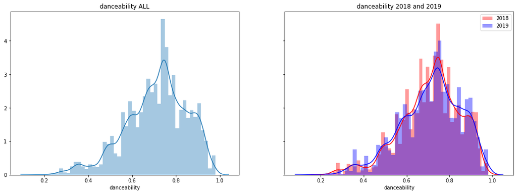

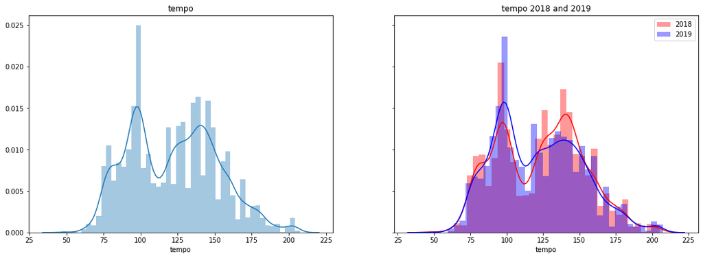

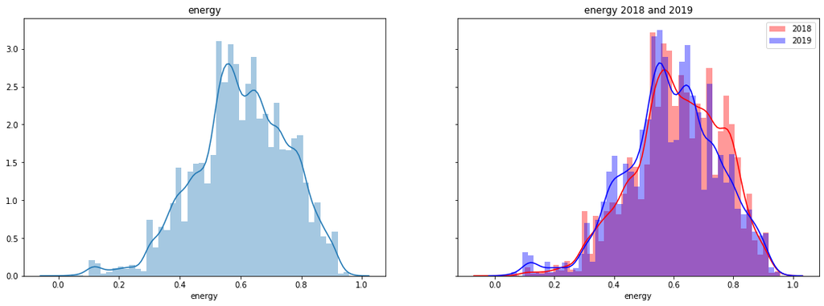

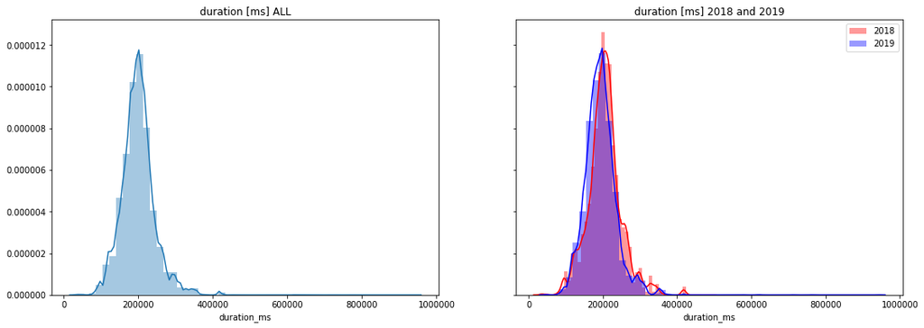

```python
f1, (ax1, ax2) = plt.subplots(1, 2, sharey=True,figsize=(18, 6))

plt.sca(ax1)
sns.distplot(dfall['danceability'])
plt.title('danceability ALL')
plt.sca(ax2)
sns.distplot(df18['danceability'],color='r')
plt.title('danceability 2018 and 2019')
sns.distplot(df19['danceability'],color='b')
ax2.legend(['2018','2019'])

f1, (ax1, ax2) = plt.subplots(1, 2, sharey=True,figsize=(18, 6))

plt.sca(ax1)
sns.distplot(dfall['tempo'])
plt.title('tempo')
plt.sca(ax2)
sns.distplot(df18['tempo'],color='r')
plt.title('tempo 2018 and 2019')
sns.distplot(df19['tempo'],color='b')
ax2.legend(['2018','2019'])

f1, (ax1, ax2) = plt.subplots(1, 2, sharey=True,figsize=(18, 6))

plt.sca(ax1)
sns.distplot(dfall['energy'])
plt.title('energy')
plt.sca(ax2)
sns.distplot(df18['energy'],color='r')
plt.title('energy 2018 and 2019')
sns.distplot(df19['energy'],color='b')
ax2.legend(['2018','2019'])


f1, (ax1, ax2) = plt.subplots(1, 2, sharey=True,figsize=(18, 6))

plt.sca(ax1)
sns.distplot(dfall['duration_ms'])
plt.title('duration [ms] ALL')
plt.sca(ax2)
sns.distplot(df18['duration_ms'],color='r')
plt.title('duration [ms] 2018 and 2019')
sns.distplot(df19['duration_ms'],color='b')
ax2.legend(['2018','2019'])
```

Observations: The graphs above show that distributions are not exactly the same from one year to the next. This confirms that we were right to consider recent years for current song predictions. However taking two years still is beter to give us a larger pool of data and longer time to test if a song becomes succesful. It is also interesting to note that although for some features the distribution is centered around a single peak, for some such as tempo, there appears to be multiple values around which density spikes. Not all features are explored in this initial overview since further EDA will be carried out with particular KPI's later on

Now what if we do the same analysis but differentiate between top 10% (20 or above) song and average hit songs

### EDA with KPI 1

The first success definition used is as follows: a song is top if reaches above top 20, which means each week we recalculate if a song is top or not. This EDA is not useful for the classification part of the project since we switched to KPI2 to classify what is a top song or not. It is kept in this report for completeness, to show the process that was carried out.

```python
df18['top'] = np.where(df18['Position']<21, 1, 0)
df19['top'] = np.where(df19['Position']<21, 1, 0)
dfall['top'] = np.where(dfall['Position']<21, 1, 0)
```

Some feature distributions were plotted to observe how the top and not top categories compare to one another

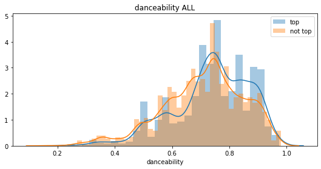

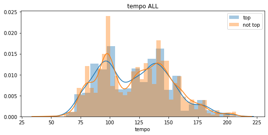

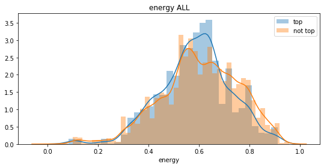

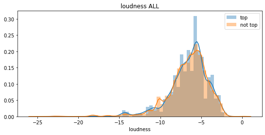

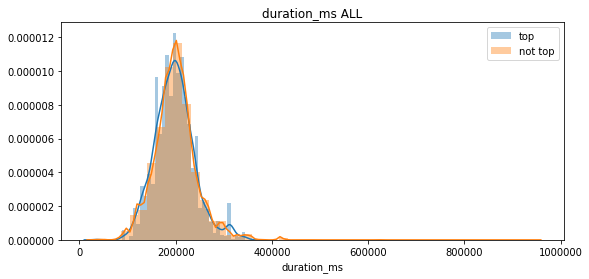

```python
features=['danceability','tempo','energy','loudness','duration_ms']

for feat in features:
    f1, (ax1) = plt.subplots(1, 1, sharey=True,figsize=(9, 4))

    plt.sca(ax1)
    df = dfall[dfall.top == 1]
    sns.distplot(df[feat], label='top')
    plt.title(feat + ' ALL')
    df = dfall[dfall.top == 0]
    sns.distplot(df[feat],label='not top')
    plt.legend()
```

#### Exploring possible time patterns

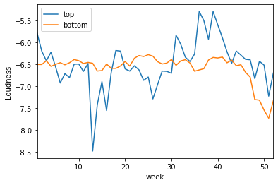

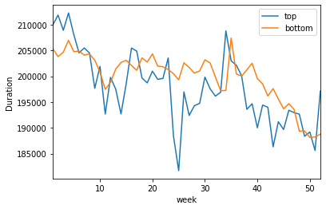

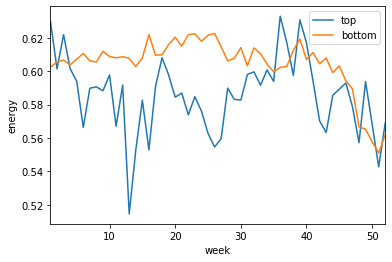

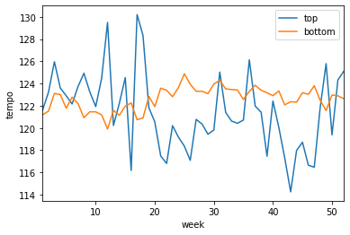

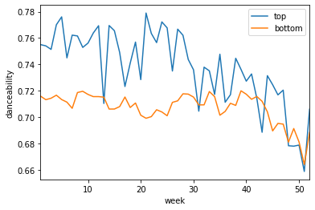

```python
dfall_top=dfall[dfall['Position']<21]
dfall_bot=dfall[dfall['Position']>=21]

ax=dfall_top.groupby('week')['loudness'].mean().plot(kind='line')
ax=dfall_bot.groupby('week')['loudness'].mean().plot(kind='line')
plt.ylabel('Loudness')
ax.legend(["top", "bottom"])

plt.figure()
ax2=dfall_top.groupby('week')['duration_ms'].mean().plot(kind='line')
ax2=dfall_bot.groupby('week')['duration_ms'].mean().plot(kind='line')
plt.ylabel('Duration')
ax2.legend(["top", "bottom"])

plt.figure()
ax4=dfall_top.groupby('week')['energy'].mean().plot(kind='line')
ax4=dfall_bot.groupby('week')['energy'].mean().plot(kind='line')
ax4.legend(["top", "bottom"])
ax4.set_ylabel('energy')

plt.figure()
ax5=dfall_top.groupby('week')['tempo'].mean().plot(kind='line')
ax5=dfall_bot.groupby('week')['tempo'].mean().plot(kind='line')
ax5.legend(["top", "bottom"])
ax5.set_ylabel('tempo')

plt.figure()
ax5=dfall_top.groupby('week')['danceability'].mean().plot(kind='line')
ax5=dfall_bot.groupby('week')['danceability'].mean().plot(kind='line')
ax5.legend(["top", "bottom"])
ax5.set_ylabel('danceability')
```

Observations: Analysing the data over time shows indeed that certain features depend on seasonality and that these variations are not identical for top and not top songs. This intuitively makes sense since different songs are popular during different periods of the year. Such time dependent observation won't nevessarily be taken into account in the classification problem since week number isn't taken into account anymore. However for regression problems it highlights the fact that week number will most likely be an important parameter to keep into account when predicting success at a given time. However we do need to keep into account that the large variations in trends between top and not top may be due to the fact we have less data points for top and thus with less samples there may be more significant variations whereas large samples tend to average out better.

### EDA with KPI 2

a new 'top' definition is now used in this section: top if number it reached top 20 (was a top) in at least one week

```python
#define nondup
dfall['top'] = np.where(dfall['Position']<21, 1, 0)
dfallnondup=dfall.sort_values('Position', ascending=True).drop_duplicates('Track Name')
dfallnondup.index = np.arange(len(dfallnondup))
dfallnondup.head()
```

|  | Position | Track Name | Artist | Streams | URL | danceability | energy | key | loudness | mode | ... | type | id | uri | track_href | analysis_url | duration_ms | time_signature | week | year | top |
| --- | --- | --- | --- | --- | --- | --- | --- | --- | --- | --- | --- | --- | --- | --- | --- | --- | --- | --- | --- | --- | --- |
| 0 | 1 | rockstar | Post Malone | 9855305 | https://open.spotify.com/track/7wGoVu4Dady5GV0... | 0.577 | 0.522 | 5 | -6.594 | 0 | ... | audio_features | 7wGoVu4Dady5GV0Sv4UIsx | spotify:track:7wGoVu4Dady5GV0Sv4UIsx | https://api.spotify.com/v1/tracks/7wGoVu4Dady5... | https://api.spotify.com/v1/audio-analysis/7wGo... | 218320 | 4 | 1 | 2018 | 1 |
| 1 | 1 | Nice For What | Drake | 19830250 | https://open.spotify.com/track/1cTZMwcBJT0Ka3U... | 0.567 | 0.913 | 8 | -6.471 | 1 | ... | audio_features | 1cTZMwcBJT0Ka3UJPXOeeN | spotify:track:1cTZMwcBJT0Ka3UJPXOeeN | https://api.spotify.com/v1/tracks/1cTZMwcBJT0K... | https://api.spotify.com/v1/audio-analysis/1cTZ... | 210926 | 4 | 15 | 2018 | 1 |
| 2 | 1 | Circles | Post Malone | 12719540 | https://open.spotify.com/track/21jGcNKet2qwijl... | 0.695 | 0.762 | 0 | -3.497 | 1 | ... | audio_features | 21jGcNKet2qwijlDFuPiPb | spotify:track:21jGcNKet2qwijlDFuPiPb | https://api.spotify.com/v1/tracks/21jGcNKet2qw... | https://api.spotify.com/v1/audio-analysis/21jG... | 215280 | 4 | 37 | 2019 | 1 |
| 3 | 1 | Better Now | Post Malone | 21229827 | https://open.spotify.com/track/7dt6x5M1jzdTEt8... | 0.680 | 0.578 | 10 | -5.804 | 1 | ... | audio_features | 7dt6x5M1jzdTEt8oCbisTK | spotify:track:7dt6x5M1jzdTEt8oCbisTK | https://api.spotify.com/v1/tracks/7dt6x5M1jzdT... | https://api.spotify.com/v1/audio-analysis/7dt6... | 231267 | 4 | 17 | 2018 | 1 |
| 4 | 1 | Lover | Taylor Swift | 12784772 | https://open.spotify.com/track/1dGr1c8CrMLDpV6... | 0.359 | 0.543 | 7 | -7.582 | 1 | ... | audio_features | 1dGr1c8CrMLDpV6mPbImSI | spotify:track:1dGr1c8CrMLDpV6mPbImSI | https://api.spotify.com/v1/tracks/1dGr1c8CrMLD... | https://api.spotify.com/v1/audio-analysis/1dGr... | 221307 | 4 | 34 | 2019 | 1 |

5 rows × 26 columns

#### Outlier detection

```python
import scipy as sp
data=dfallnondup[['danceability','energy','loudness','speechiness','acousticness','instrumentalness','liveness','duration_ms','valence','tempo',]]
cov = np.cov(data, rowvar=False)
inv_cov = sp.linalg.inv(cov)
list(data.mean(axis=0))
vars_mean = []
for i in range (2177):
    vars_mean.append(list(data.mean(axis=0)))
vars_mean=np.array(vars_mean)
m=data-vars_mean
mvalue=[]
for i in range(2177):
    x=np.array(m.iloc[0])
    mvalue.append(np.sqrt(x.dot(inv_cov).dot(x)))
data['mahala']=list(mvalue)
data.head()
from scipy.stats import chi2
crit=chi2.ppf((1-0.01), df=10)
data.loc[data.mahala > np.sqrt(crit)].shape
```

```
(0, 11)
```

#### Data visualization

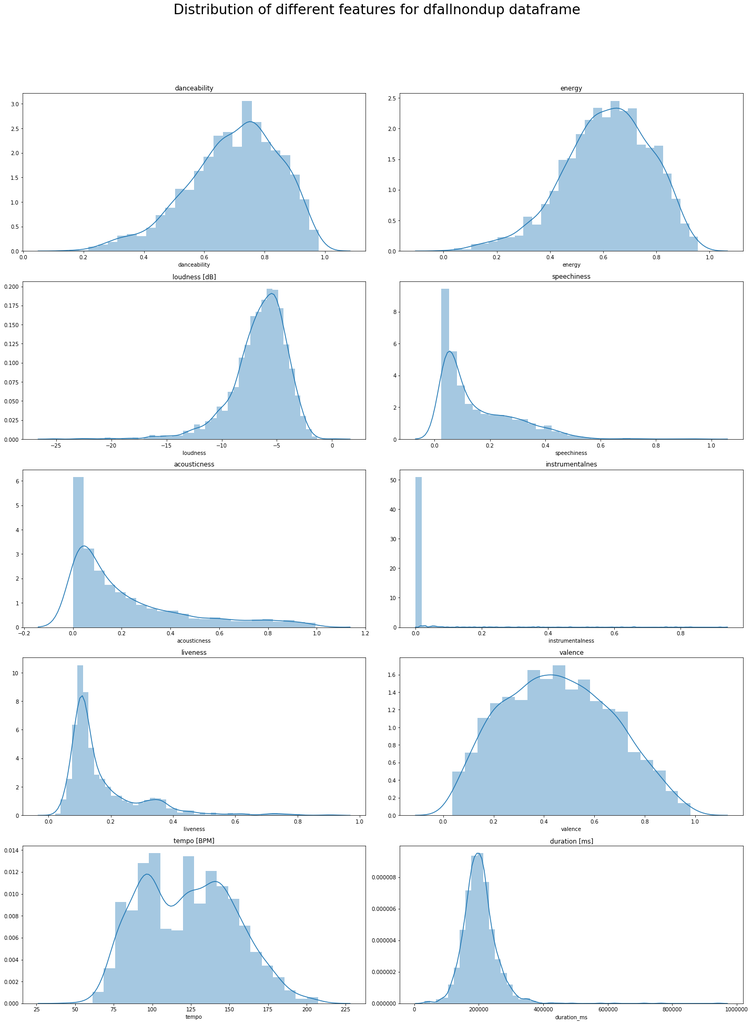

```python
f1, ((ax1, ax2),(ax3,ax4), (ax5, ax6), (ax7,ax8),(ax9,ax10)) = plt.subplots(5, 2,figsize=(20, 25))

plt.sca(ax1)
sns.distplot(dfallnondup['danceability'])
plt.title('danceability')

plt.sca(ax2)
sns.distplot(dfallnondup['energy'])
plt.title('energy')

plt.sca(ax3)
sns.distplot(dfallnondup['loudness'])
plt.title('loudness [dB]')

plt.sca(ax4)
sns.distplot(dfallnondup['speechiness'])
plt.title('speechiness')

plt.sca(ax5)
sns.distplot(dfallnondup['acousticness'])
plt.title('acousticness')

plt.sca(ax6)
sns.distplot(dfallnondup['instrumentalness'])
plt.title('instrumentalnes')

plt.sca(ax7)
sns.distplot(dfallnondup['liveness'])
plt.title('liveness')

plt.sca(ax8)
sns.distplot(dfallnondup['valence'])
plt.title('valence')

plt.sca(ax9)
sns.distplot(dfallnondup['tempo'])
plt.title('tempo [BPM]')

plt.sca(ax10)
sns.distplot(dfallnondup['duration_ms'])
plt.title('duration [ms]')


f1.suptitle('Distribution of different features for dfallnondup dataframe', fontsize=26,y=1.08)
plt.tight_layout()
```

Observations: We see that in some cases the normality assumption use for mahalanobis distance outlier test is not appropriate for example when there are two peaks (tempo) or exponentially decreasing distributions such as for 'speechiness'. This full view of distributions for different features shows how different features are distributed in multiple shapes across our song samples.

#### Comparing distribution for top and not top songs

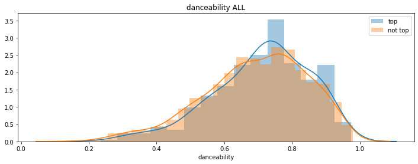

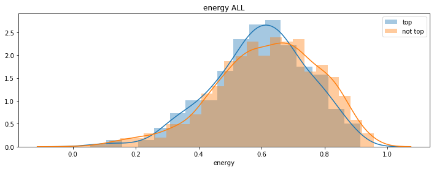

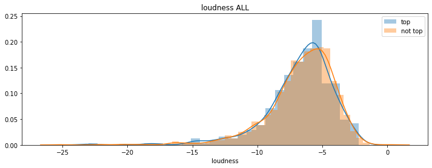

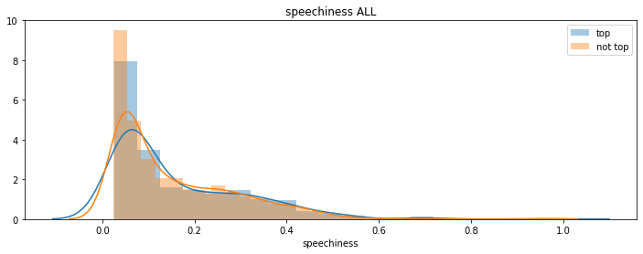

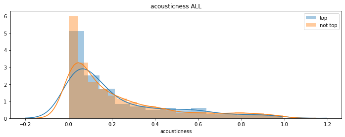

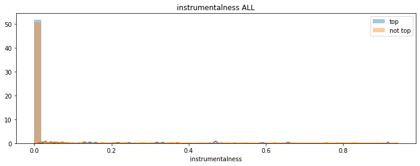

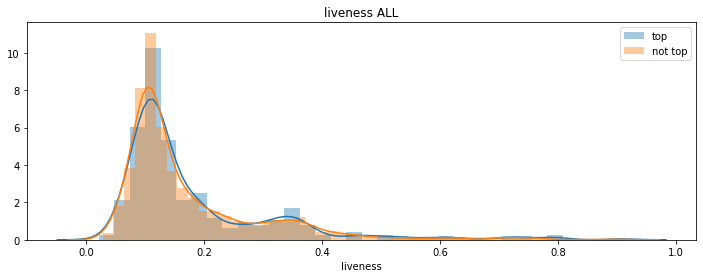

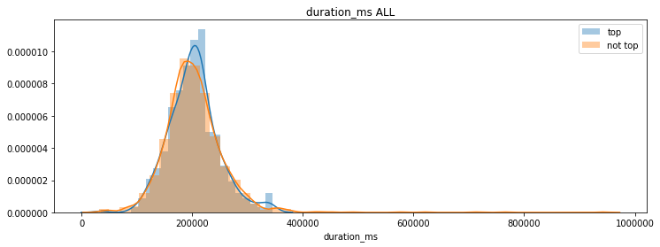

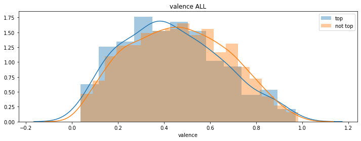

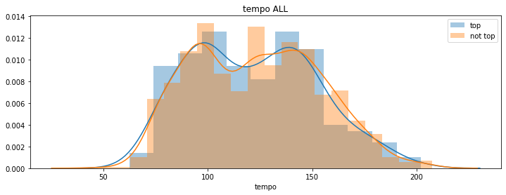

```python
features=['danceability','energy','loudness','speechiness','acousticness','instrumentalness','liveness','duration_ms','valence','tempo',]

for feat in features:
    f1, (ax1) = plt.subplots(1, 1,figsize=(12, 4))

    plt.sca(ax1)
    df = dfallnondup[dfallnondup.top == 1]
    sns.distplot(df[feat], label='top')
    plt.title(feat + ' ALL')
    df = dfallnondup[dfallnondup.top == 0]
    sns.distplot(df[feat],label='not top')
    plt.legend()
```